# Bayesian Homework 2

### Alex Yang - zy7ts

## Part I

### 1. density plot for 2 continuous vars

```r
library(tidyverse)
```

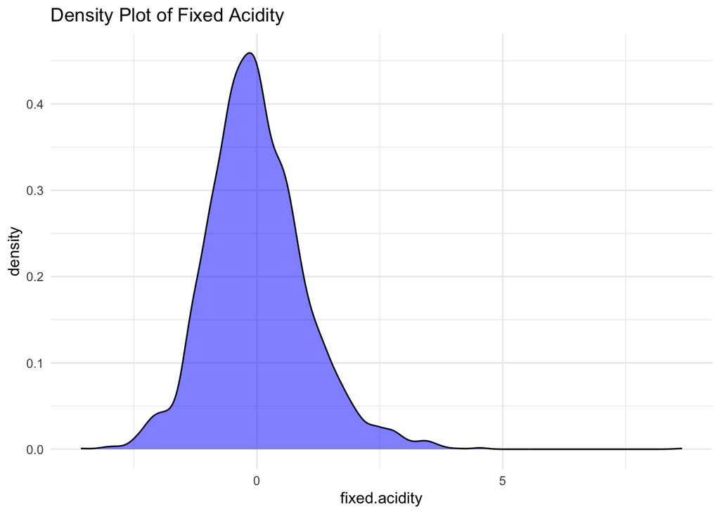

```r
data <- read.csv("whitewine-training-ds6040.csv")

ggplot(data, aes(x = fixed.acidity)) +
  geom_density(fill = "blue", alpha = 0.5) +
  ggtitle("Density Plot of Fixed Acidity") +
  theme_minimal()
```

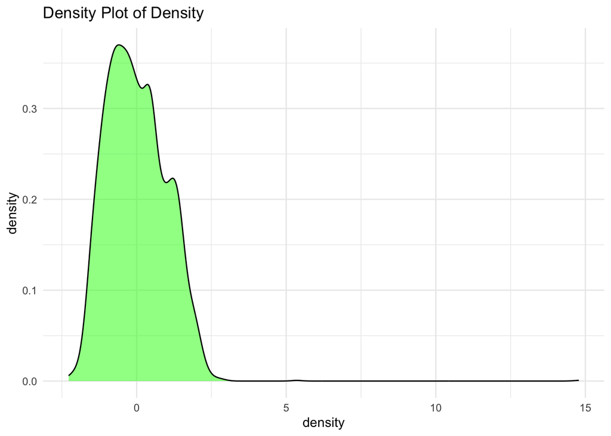

```r
ggplot(data, aes(x = density)) +
  geom_density(fill = "green", alpha = 0.5) +
  ggtitle("Density Plot of Density") +
  theme_minimal()
```

### 2. Calculating the posterior distribution

The conjugate prior for a normal likelihood is also a normal distribution. I then looked up the formula online for calculation with know variance (known variance is calculated below)

```r
var_fixed_acidity <- var(data$fixed.acidity)
var_density <- var(data$density)

posterior_calculator <- function(data, prior_mean, prior_precision, likelihood_variance) {
  n <- length(data)
  sample_mean <- mean(data)

  posterior_precision <- prior_precision + n / likelihood_variance
  posterior_mean <- (prior_precision * prior_mean + (n / likelihood_variance) * sample_mean) / posterior_precision

  return(list(mean = posterior_mean, precision = posterior_precision))
}

# Uninformative prior for fixed acidity
posterior_acidity_uninform <- posterior_calculator(
  data$fixed.acidity,
  prior_mean = 0,
  prior_precision = 0.01,
  likelihood_variance = var_fixed_acidity
)

# Informative prior for fixed acidity
posterior_acidity_inf <- posterior_calculator(
  data$fixed.acidity,
  prior_mean = 10,
  prior_precision = 100,
  likelihood_variance = var_fixed_acidity
)

# Uninformative prior for density
posterior_density_uninform <- posterior_calculator(
  data$density,
  prior_mean = 0,
  prior_precision = 0.01,
  likelihood_variance = var_fixed_acidity
)

# Informative prior for density
posterior_density_inf <- posterior_calculator(
  data$density,
  prior_mean = 10,
  prior_precision = 100,
  likelihood_variance = var_fixed_acidity
)

# Print results
cat("Fixed Acidity Posteriors:\n")
```

```
## Fixed Acidity Posteriors:
```

```r
cat("Uninformative: Mean =", posterior_acidity_uninform$mean, ", Precision =", posterior_acidity_uninform$precision, "\n")
```

```
## Uninformative: Mean = -2.805243e-16 , Precision = 3178.01
```

```r
cat("Informative: Mean =", posterior_acidity_inf$mean, ", Precision =", posterior_acidity_inf$precision, "\n")
```

```
## Informative: Mean = 0.3050641 , Precision = 3278
```

```r
cat("Density Posteriors:\n")
```

```
## Density Posteriors:
```

```r
cat("Uninformative: Mean =", posterior_density_inf$mean, ", Precision =", posterior_density_uninform$precision, "\n")
```

```
## Uninformative: Mean = 0.3050641 , Precision = 3178.01
```

```r
cat("Informative: Mean =", posterior_density_inf$mean, ", Precision =", posterior_acidity_inf$precision, "\n")
```

```
## Informative: Mean = 0.3050641 , Precision = 3278
```

### 3. Impacts of hyperparameters and “bad” hyperparameters

> When we chose the informative and uninformative priors for the fixed.acidity variable even though the posterior mean moves away from each other but it’s not by a significant margin. However, it is still possible to choose a “bad” hyperparameter let’s say one chooses 10,000 for the prior precision that would easily dominate the data and lead the posterior away from the true population parameters. If we use more extreme priors we can potentially see a biased estimation of true population parameters

### 4. Repeat previous steps but with exponential likelihood

note: I used Claude.ai here initially to tackle the code

```r
lambda_fixed_acidity <- 1 / mean(data$fixed.acidity)
lambda_density <- 1 / mean(data$density)

posterior_gamma <- function(data, prior_gamma, prior_beta) {
  n <- length(data)
  sum_x <- sum(data)

  posterior_gamma <- prior_gamma + n
  posterior_beta <- prior_beta + sum_x

  return(list(gamma = posterior_gamma, beta = posterior_beta))
}

# posteriors for fixed acidity
# Uninformative prior
posterior_acidity_uninform <- posterior_gamma(
  data$fixed.acidity,
  prior_gamma = 0.01,
  prior_beta = 0.01
)

# Informative prior
posterior_acidity_inform <- posterior_gamma(
  data$fixed.acidity,
  prior_gamma = 10,
  prior_beta = 1
)

# posteriors for density
# Uninformative prior
posterior_density_uninform <- posterior_gamma(
  data$density,
  prior_gamma = 0.01,
  prior_beta = 0.01
)

# Informative prior
posterior_density_inform <- posterior_gamma(
  data$density,
  prior_gamma = 1000,
  prior_beta = 1000
)

calculate_stats <- function(posterior) {
  list(
    mean = posterior$gamma / posterior$beta,
    variance = posterior$gamma / (posterior$beta^2)
  )
}

stats_list <- lapply(
  list(
    acidity_uninform = posterior_acidity_uninform,
    acidity_inform = posterior_acidity_inform,
    density_uninform = posterior_density_uninform,
    density_inform = posterior_density_inform
  ),
  calculate_stats
)

# Extract individual statistics from the stats_list
stats_acidity_uninform <- stats_list$acidity_uninform
stats_acidity_inform <- stats_list$acidity_inform
stats_density_uninform <- stats_list$density_uninform
stats_density_inform <- stats_list$density_inform

# Print results
cat("Fixed Acidity Posteriors (Exponential Likelihood):\n")
```

```
## Fixed Acidity Posteriors (Exponential Likelihood):
```

```r
cat("Uninformative: Gamma =", posterior_acidity_uninform$gamma, ", Beta =", posterior_acidity_uninform$beta, "\n")
```

```
## Uninformative: Gamma = 3178.01 , Beta = 0.01
```

```r
cat("  Mean =", stats_acidity_uninform$mean, ", Variance =", stats_acidity_uninform$variance, "\n")
```

```
##   Mean = 317801 , Variance = 31780100
```

```r
cat("Informative: Gamma =", posterior_acidity_inform$gamma, ", Beta =", posterior_acidity_inform$beta, "\n")
```

```
## Informative: Gamma = 3188 , Beta = 1
```

```r
cat("  Mean =", stats_acidity_inform$mean, ", Variance =", stats_acidity_inform$variance, "\n\n")
```

```
##   Mean = 3188 , Variance = 3188
```

```r
cat("Density Posteriors (Exponential Likelihood):\n")
```

```
## Density Posteriors (Exponential Likelihood):
```

```r
cat("Uninformative: Gamma =", posterior_density_uninform$gamma, ", Beta =", posterior_density_uninform$beta, "\n")
```

```
## Uninformative: Gamma = 3178.01 , Beta = 0.01
```

```r
cat("  Mean =", stats_density_uninform$mean, ", Variance =", stats_density_uninform$variance, "\n")
```

```
##   Mean = 317801 , Variance = 31780100
```

```r
cat("Informative: Gamma =", posterior_density_inform$gamma, ", Beta =", posterior_density_inform$beta, "\n")
```

```
## Informative: Gamma = 4178 , Beta = 1000
```

```r
cat("  Mean =", stats_density_inform$mean, ", Variance =", stats_density_inform$variance, "\n")
```

```
##   Mean = 4.178 , Variance = 0.004178
```

### 5. Impacts of hyperparameter

> same thing as before the hyperparameter choices could influence the posterior distribution significantly. We see from our results that uninformative priors lead to very high mean and variances for both fixed acidity and density. While the informative priors ended up with a result that seems more reasonable. The results we got from this shows how sensitive the posterior is like with the changing hyperparameters showcasing the importance of choosing the correct prior and hyperparameters

### 6. How do values differ between the two

> we can see the exponential likelihood models results in a higher mean and variance. This shows that there is a higher uncertainty in predicting the posterior expected values compared to the normal model

## Part II

### 1. Interpretation of α

> i believe that the value of alpha is our prior belief about how likely each category (A,C,F) is going to happen. For example, a bigger value of alpha for category A might mean that we believe that there is a higher chance of A being observed.

### 2. Observation Generation & Plotting

```r
library(dirmult)
library(reshape2)
# counts for each category
n <- as.numeric(table(data$wine_quality))

# setting informative and uninformative alphas
alpha_uninformative <- c(A=1, C=1, F=1)
alpha_informative <- c(A = 500000, B = 500000, C = 500000)

# setting posterior parameters
posterior_uninformative <- alpha_uninformative + n
posterior_informative <- alpha_informative + n

# generate samples
samples_uninformative <- rdirichlet(1000, posterior_uninformative)
samples_informative <- rdirichlet(1000, posterior_informative)

# dataframe conversion and melting
df_uninformative <- as.data.frame(samples_uninformative)
df_informative <- as.data.frame(samples_informative)
colnames(df_uninformative) <- c("A", "C", "F")
colnames(df_informative) <- c("A", "C", "F")
df_uninformative_melt <- melt(df_uninformative, variable.name = "Grade", value.name = "Proportion")
df_informative_melt <- melt(df_informative, variable.name = "Grade", value.name = "Proportion")
```

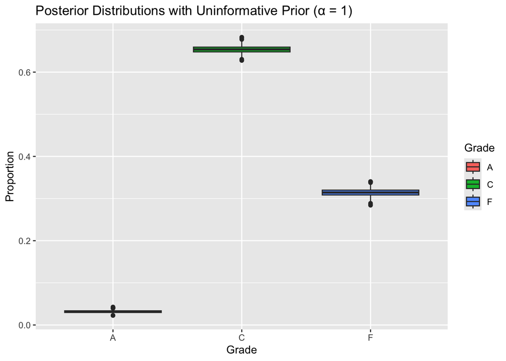

```r
# uninformative prior plotting
ggplot(df_uninformative_melt, aes(x = Grade, y = Proportion, fill = Grade)) +
  geom_boxplot() +
  ggtitle("Posterior Distributions with Uninformative Prior (α = 1)")
```

[figure not shown]

```r
# informative prior plotting
ggplot(df_informative_melt, aes(x = Grade, y = Proportion, fill = Grade)) +
  geom_boxplot() +
  ggtitle("Posterior Distributions with Informative Prior (α = 50)")
```

### 3. Comment on the impact of prior choice

> I see that for the informative prior we have a smaller range of variability across all three categories compared to the uninformative prior which has a wider spread of proportions across all three categories.

## Part III

### 1. hyperparameters

```r
alcohol_A <- data$alcohol[data$wine_quality == "A"]
alcohol_F <- data$alcohol[data$wine_quality == "F"]

# Calculate variances
var_A <- var(alcohol_A)
var_F <- var(alcohol_F)

# Uninformative priors
prior_mean_uninf <- 0
prior_precision_uninf <- 0.01

# Informative priors
prior_mean_inf <- 12  # assuming average wine alcohol content around 12%
prior_precision_inf <- 10  # higher precision for more informative prior
```

### 2&3 Posterior distribution for alcohol contents with F rating

```r
# Calculate posteriors
post_A_uninf <- posterior_calculator(alcohol_A, prior_mean_uninf, prior_precision_uninf, var_A)
post_F_uninf <- posterior_calculator(alcohol_F, prior_mean_uninf, prior_precision_uninf, var_F)
post_A_inf <- posterior_calculator(alcohol_A, prior_mean_inf, prior_precision_inf, var_A)
post_F_inf <- posterior_calculator(alcohol_F, prior_mean_inf, prior_precision_inf, var_F)

# Calculate
diff_uninf_mean <- post_A_uninf$mean - post_F_uninf$mean
diff_uninf_var <- post_A_uninf$precision + post_F_uninf$precision
diff_inf_mean <- post_A_inf$mean - post_F_inf$mean
diff_inf_var <- post_A_inf$precision + post_F_inf$precision

cat("uninformed prior mean difference is", diff_uninf_mean, '\n')
```

```
## uninformed prior mean difference is 1.463016
```

```r
cat('uninformed prior variance difference is', diff_uninf_var, '\n')
```

```
## uninformed prior variance difference is 2013.106
```

```r
cat('informed prior mean difference is', diff_inf_mean, '\n')
```

```
## informed prior mean difference is 2.482373
```

```r
cat('informed prior variance difference is', diff_inf_var)
```

```
## informed prior variance difference is 2033.086
```

### 4. 95% HDI and plotting

```r
calculate_hdi <- function(mean, variance, ci = 0.95) {
  alpha <- 1 - ci
  z_score <- qnorm(1 - alpha/2)
  margin <- z_score * sqrt(variance)
  lower <- mean - margin
  upper <- mean + margin
  return(c(lower, upper))
}

# Calculate 95% HDI for both prior choices
hdi_uninf <- calculate_hdi(diff_uninf_mean, diff_uninf_var)
hdi_inf <- calculate_hdi(diff_inf_mean, diff_inf_var)

cat("\n95% HDI for uninformative prior:", hdi_uninf[1], "to", hdi_uninf[2], "\n")
```

```
##
## 95% HDI for uninformative prior: -86.47597 to 89.402
```

```r
cat("95% HDI for informative prior:", hdi_inf[1], "to", hdi_inf[2], "\n")
```

```
## 95% HDI for informative prior: -85.89193 to 90.85667
```

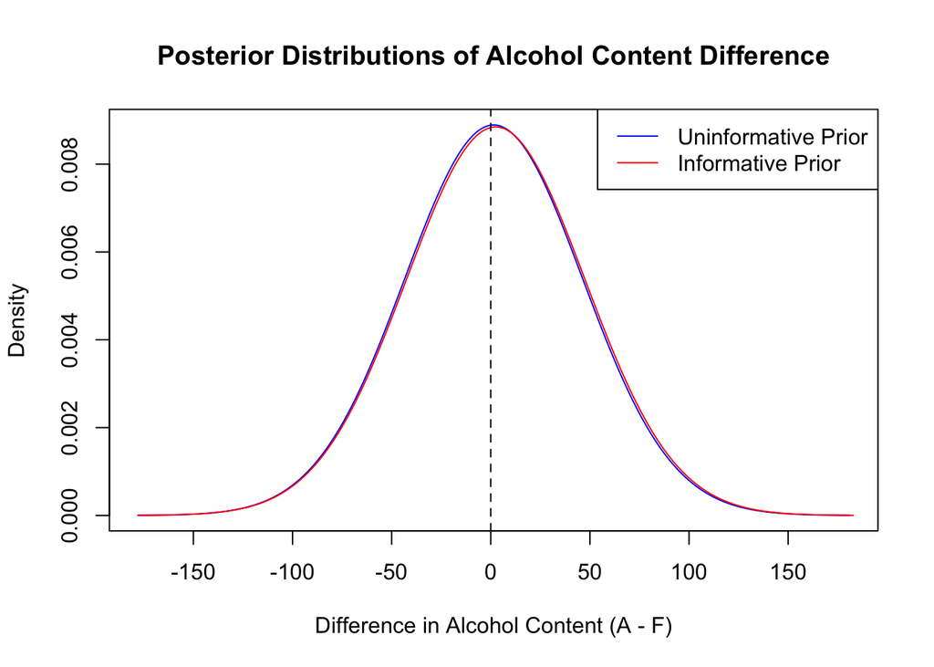

```r
# Visualize the posterior distributions
x_uninf <- seq(diff_uninf_mean - 4*sqrt(diff_uninf_var), diff_uninf_mean + 4*sqrt(diff_uninf_var), length.out = 1000)
y_uninf <- dnorm(x_uninf, diff_uninf_mean, sqrt(diff_uninf_var))

x_inf <- seq(diff_inf_mean - 4*sqrt(diff_inf_var), diff_inf_mean + 4*sqrt(diff_inf_var), length.out = 1000)
y_inf <- dnorm(x_inf, diff_inf_mean, sqrt(diff_inf_var))

plot(x_uninf, y_uninf, type = "l", col = "blue", xlab = "Difference in Alcohol Content (A - F)", ylab = "Density", main = "Posterior Distributions of Alcohol Content Difference")
lines(x_inf, y_inf, col = "red")
legend("topright", legend = c("Uninformative Prior", "Informative Prior"), col = c("blue", "red"), lty = 1)
abline(v = 0, lty = 2)
```

> surprisingly the prior choises didn’t impact the distribution all that much.. I need to see the answer key and dive deeper into why this doesn’t make sense later!